# 123

## Imports

```python
import pandas as pd
import matplotlib.pyplot as plt
import seaborn as sns
%matplotlib inline
import numpy as np
from sklearn.linear_model import LinearRegression
from scipy import stats
from dask import dataframe as dd
```

## Setting the data

```python
weather = pd.read_csv('weather.csv', sep=',')
# filter weather data to include only the columns we can use
weather = weather[['date', 'mean_temperature_f','mean_dew_point_f', 'mean_humidity', 'mean_visibility_miles', 'mean_wind_speed_mph', 'precipitation_inches', 'zip_code']]
weather.info()
```

```
<class 'pandas.core.frame.DataFrame'>
RangeIndex: 3665 entries, 0 to 3664
Data columns (total 8 columns):
 #   Column                 Non-Null Count  Dtype
---  ------                 --------------  -----
 0   date                   3665 non-null   object
 1   mean_temperature_f     3661 non-null   float64
 2   mean_dew_point_f       3611 non-null   float64
 3   mean_humidity          3611 non-null   float64
 4   mean_visibility_miles  3652 non-null   float64
 5   mean_wind_speed_mph    3664 non-null   float64
 6   precipitation_inches   3664 non-null   object
 7   zip_code               3665 non-null   int64
dtypes: float64(5), int64(1), object(2)
memory usage: 229.2+ KB
```

```python
trip = pd.read_csv('trip.csv', sep=',')
trip.info()
```

```
<class 'pandas.core.frame.DataFrame'>
RangeIndex: 669959 entries, 0 to 669958
Data columns (total 11 columns):
 #   Column              Non-Null Count   Dtype
---  ------              --------------   -----
 0   id                  669959 non-null  int64
 1   duration            669959 non-null  int64
 2   start_date          669959 non-null  object
 3   start_station_name  669959 non-null  object
 4   start_station_id    669959 non-null  int64
 5   end_date            669959 non-null  object
 6   end_station_name    669959 non-null  object
 7   end_station_id      669959 non-null  int64
 8   bike_id             669959 non-null  int64
 9   subscription_type   669959 non-null  object
 10  zip_code            663340 non-null  object
dtypes: int64(5), object(6)
memory usage: 56.2+ MB
```

```python
status = pd.read_csv('status.csv', sep=',')
# status.head(10)
```

```python
station = pd.read_csv('station.csv', sep=',')
station.head(10)
```

|  | id | name | lat | long | dock_count | city | installation_date |
| --- | --- | --- | --- | --- | --- | --- | --- |
| 0 | 2 | San Jose Diridon Caltrain Station | 37.329732 | -121.901782 | 27 | San Jose | 8/6/2013 |
| 1 | 3 | San Jose Civic Center | 37.330698 | -121.888979 | 15 | San Jose | 8/5/2013 |
| 2 | 4 | Santa Clara at Almaden | 37.333988 | -121.894902 | 11 | San Jose | 8/6/2013 |
| 3 | 5 | Adobe on Almaden | 37.331415 | -121.893200 | 19 | San Jose | 8/5/2013 |
| 4 | 6 | San Pedro Square | 37.336721 | -121.894074 | 15 | San Jose | 8/7/2013 |
| 5 | 7 | Paseo de San Antonio | 37.333798 | -121.886943 | 15 | San Jose | 8/7/2013 |
| 6 | 8 | San Salvador at 1st | 37.330165 | -121.885831 | 15 | San Jose | 8/5/2013 |
| 7 | 9 | Japantown | 37.348742 | -121.894715 | 15 | San Jose | 8/5/2013 |
| 8 | 10 | San Jose City Hall | 37.337391 | -121.886995 | 15 | San Jose | 8/6/2013 |
| 9 | 11 | MLK Library | 37.335885 | -121.885660 | 19 | San Jose | 8/6/2013 |

```python
status_1 = dd.read_csv('status.csv', sep=',')
status_1.info()
```

```
<class 'dask.dataframe.core.DataFrame'>
Columns: 4 entries, station_id to time
dtypes: object(1), int64(3)
```

```python
station = pd.read_csv('station.csv', sep=',')
station_dict=dict(zip(station.id,station.name))
```

## 1) Effects of weather on bikeshare trips

Hypothesis : Days with better weather had longer and a greater number of rides vs the days with bad weather

```python
# Clean the data
# fix null zip codes for trips
trip.zip_code = trip.zip_code.replace(np.nan, 0)

# convert dates to datetime objects
trip.start_date = pd.to_datetime(trip['start_date']).dt.date
trip.end_date = pd.to_datetime(trip['end_date']).dt.date
weather.date = pd.to_datetime(weather['date']).dt.date

# convert weather zipcodes to string
weather.zip_code = weather.zip_code.astype(str)

# convert precipitation to float and replace null values
weather.precipitation_inches = weather.precipitation_inches.str.extract('(\d+)').astype(float).replace(np.nan, 0)
weather.mean_temperature_f = weather.mean_temperature_f.replace(np.nan, 0)
weather.mean_dew_point_f = weather.mean_dew_point_f.replace(np.nan, 0)
weather.mean_humidity = weather.mean_humidity.replace(np.nan, 0)
weather.mean_visibility_miles = weather.mean_visibility_miles.replace(np.nan, 0)
weather.mean_wind_speed_mph = weather.mean_wind_speed_mph.replace(np.nan, 0)
```

```python
#filter the data to only consider zip codes for which the weather data is available
tripWeather = trip.loc[trip.zip_code.isin(weather.zip_code)]

# ensure trip dates for which weather data is available
tripWeather = tripWeather.loc[trip['start_date'] >= weather['date'].min()]
tripWeather = tripWeather.loc[trip['end_date'] <= weather['date'].max()]

tripWeather = tripWeather.rename(columns={'start_date': 'date'})

# Add a calculated column for total trips for a date
tripWeatherDur = tripWeather.groupby(['zip_code', 'date'])['duration'].sum().reset_index(name = 'duration')
tripWeather = tripWeather.groupby(['zip_code', 'date'])['id'].count().reset_index(name = 'total')


# # # Merge the trip and weather dataframes
tripWeather = tripWeather.merge(weather, how='inner', on=['date', 'zip_code'])
tripWeatherDur = tripWeatherDur.merge(weather, how='inner', on=['date', 'zip_code'])

# find the mean values for all zip codes
tripWeatherMean = tripWeather.groupby('date').aggregate('mean').reset_index()
tripWeatherDurMean = tripWeatherDur.groupby('date').aggregate('mean').reset_index()
```

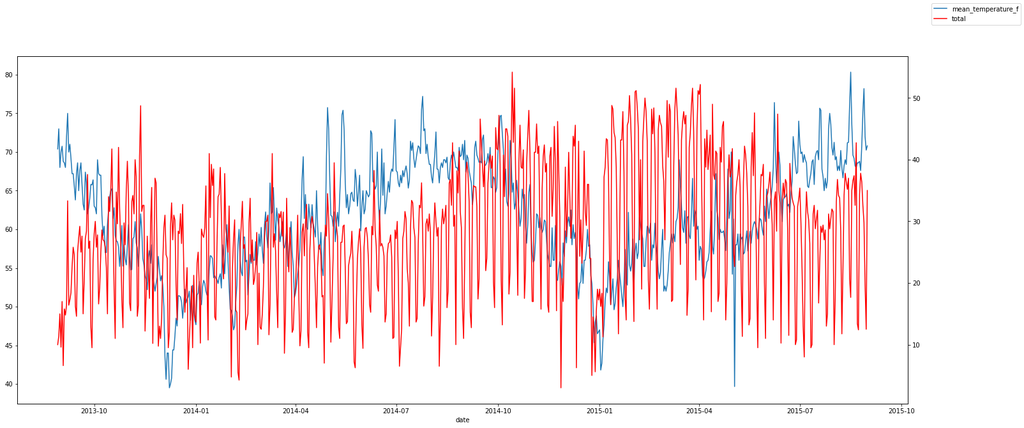

```python
# Plot mean weather vs trips
ax = tripWeatherMean.plot(x="date", y="mean_temperature_f", legend=False, figsize=(25,10))
ax2 = ax.twinx()
tripWeatherMean.plot(x="date", y="total", ax=ax2, legend=False, color="r", figsize=(25,10))
ax.figure.legend()
```

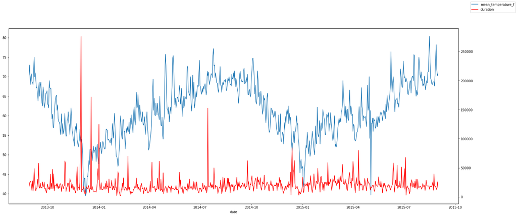

```python
# Plot mean weather vs duration
ax = tripWeatherDurMean.plot(x="date", y="mean_temperature_f", legend=False, figsize=(25,10))
ax2 = ax.twinx()
tripWeatherDurMean.plot(x="date", y="duration", ax=ax2, legend=False, color="r", figsize=(25,10))
ax.figure.legend()
```

```python
# Compute the regression between weather and number of trips and individual correlation between elements
X = tripWeatherMean.iloc[:, 3:]
temp = tripWeatherMean.mean_temperature_f
dew = tripWeatherMean.mean_dew_point_f
humidity = tripWeatherMean.mean_humidity
visibility = tripWeatherMean.mean_visibility_miles
wind = tripWeatherMean.mean_wind_speed_mph
prec = tripWeatherMean.precipitation_inches
y = tripWeatherMean.iloc[:, 2]
reg = LinearRegression().fit(X, y)
print('Reg = ', reg.score(X, y))
print('Temp = ', y.corr(temp))
print('Dew = ', y.corr(dew))
print('Humidity = ', y.corr(humidity))
print('Visibility = ', y.corr(visibility))
print('Wind = ', y.corr(wind))
print('Precipitation = ', y.corr(prec))
```

```
Reg =  0.9464708283124099
Temp =  0.9999999999999999
Dew =  0.7592262037689402
Humidity =  -0.07594318190548228
Visibility =  0.26651548908687483
Wind =  0.3556310916321216
Precipitation =  -0.027576545114502797
```

```python
# Compute the regression between weather and duration of trips and individual correlation between elements
X = tripWeatherDurMean.iloc[:, 3:]
temp = tripWeatherDurMean.mean_temperature_f
dew = tripWeatherDurMean.mean_dew_point_f
humidity = tripWeatherDurMean.mean_humidity
visibility = tripWeatherDurMean.mean_visibility_miles
wind = tripWeatherDurMean.mean_wind_speed_mph
prec = tripWeatherDurMean.precipitation_inches
y = tripWeatherDurMean.iloc[:, 2]
reg = LinearRegression().fit(X, y)
print('Reg = ', reg.score(X, y))
print('Temp = ', y.corr(temp))
print('Dew = ', y.corr(dew))
print('Humidity = ', y.corr(humidity))
print('Visibility = ', y.corr(visibility))
print('Wind = ', y.corr(wind))
print('Precipitation = ', y.corr(prec))
```

```
Reg =  0.9464708283124099
Temp =  0.9999999999999999
Dew =  0.7592262037689402
Humidity =  -0.07594318190548228
Visibility =  0.26651548908687483
Wind =  0.3556310916321216
Precipitation =  -0.027576545114502797
```

## 2) Most popular stations

```python
# Check the data
status.info()
station.info()
station.isnull().count()
```

```
<class 'pandas.core.frame.DataFrame'>
RangeIndex: 71984434 entries, 0 to 71984433
Data columns (total 4 columns):
 #   Column           Dtype
---  ------           -----
 0   station_id       int64
 1   bikes_available  int64
 2   docks_available  int64
 3   time             object
dtypes: int64(3), object(1)
memory usage: 2.1+ GB
<class 'pandas.core.frame.DataFrame'>
RangeIndex: 70 entries, 0 to 69
Data columns (total 7 columns):
 #   Column             Non-Null Count  Dtype
---  ------             --------------  -----
 0   id                 70 non-null     int64
 1   name               70 non-null     object
 2   lat                70 non-null     float64
 3   long               70 non-null     float64
 4   dock_count         70 non-null     int64
 5   city               70 non-null     object
 6   installation_date  70 non-null     object
dtypes: float64(2), int64(2), object(3)
memory usage: 4.0+ KB
```

```
id                   70
name                 70
lat                  70
long                 70
dock_count           70
city                 70
installation_date    70
dtype: int64
```

```python
#This shows us how long each station has no bikes to be used by customers
empty_bikes = status.loc[status.bikes_available ==0]
```

```python
#We only need the idle time from this data set, so we remove unncessary columns
empty_bikes.drop(columns = ["docks_available", "bikes_available"],axis =1, inplace=True)

time_empty = pd.DataFrame()
time_empty = empty_bikes.groupby(empty_bikes.station_id).count()
time_empty.rename({'time':"Hours without available bikes"},axis=1, inplace = True)
time_empty['Hours without available bikes'] = time_empty['Hours without available bikes'].divide(60).round(1)
```

```python
#Top 30 of stations that do not have enough available bikes to fully utilize the demand.
time_empty.sort_values(ascending=False, by = 'Hours without available bikes').head(30)
```

| station_id | Hours without available bikes |
| --- | --- |
| 45 | 486.6 |
| 76 | 412.1 |
| 48 | 406.7 |
| 62 | 401.3 |
| 60 | 385.7 |
| 70 | 362.1 |
| 73 | 345.6 |
| 41 | 318.0 |
| 82 | 297.1 |
| 64 | 285.2 |
| 71 | 247.8 |
| 54 | 246.8 |
| 56 | 238.0 |
| 63 | 231.9 |
| 65 | 223.7 |
| 75 | 220.4 |
| 55 | 213.2 |
| 47 | 211.4 |
| 67 | 200.5 |
| 69 | 199.8 |
| 66 | 190.7 |
| 4 | 177.0 |
| 51 | 176.4 |
| 50 | 171.8 |
| 32 | 166.6 |
| 10 | 163.7 |
| 72 | 138.1 |
| 74 | 128.1 |
| 42 | 116.4 |
| 57 | 115.6 |

```python
#Summarizing number of trips per station ID
trips_end = pd.DataFrame()
trips_start = pd.DataFrame()
trips_start['start_station_id']= trip['start_station_id']
trips_start['duration']= trip['duration']
trips_end['end_station_id']= trip['end_station_id']
trips_end['Number of Services']=trip['duration']
```

```python
#Since we know how many trips are taken from each station we can create a data frame summarizing how many times a station
#is being used and add additional metrics to clearly see which stations are the most popular and if they are being properly
#utilized by adding the number of hours that bike station has been vacant.
most_trips = trips_start.groupby(trips_start.start_station_id).count().sort_values(ascending=False,
                                                                                   by = 'duration')
longest_trips = trips_start.groupby(trips_start.start_station_id).mean().round(1).sort_values(ascending=False,
                                                                                   by = 'duration')
trip = pd.DataFrame()
trip['Number of Services'] = most_trips['duration']
trip['Average Duration of Rides'] = longest_trips['duration']
trip['Hours without available bikes'] = time_empty['Hours without available bikes']
trip.head(30)
```

| start_station_id | Number of Services | Average Duration of Rides | Hours without available bikes |
| --- | --- | --- | --- |
| 70 | 49092 | 826.6 | 362.1 |
| 69 | 33742 | 690.1 | 199.8 |
| 50 | 32934 | 1495.0 | 171.8 |
| 60 | 27713 | 1411.3 | 385.7 |
| 55 | 26089 | 655.4 | 213.2 |
| 61 | 25837 | 791.7 | 87.0 |
| 74 | 24838 | 935.7 | 128.1 |
| 77 | 24172 | 923.2 | 73.9 |
| 65 | 23724 | 676.5 | 223.7 |
| 67 | 20272 | 1049.2 | 200.5 |
| 76 | 20165 | 1309.4 | 412.1 |
| 64 | 18496 | 687.9 | 285.2 |
| 39 | 18378 | 1392.9 | 74.8 |
| 73 | 16306 | 1199.9 | 345.6 |
| 62 | 15940 | 581.7 | 401.3 |
| 56 | 15709 | 861.7 | 238.0 |
| 54 | 14811 | 1006.4 | 246.8 |
| 72 | 14102 | 1216.5 | 138.1 |
| 51 | 14054 | 830.8 | 176.4 |
| 57 | 13526 | 927.3 | 115.6 |
| 63 | 13163 | 749.0 | 231.9 |
| 66 | 12880 | 2401.6 | 190.7 |
| 71 | 12496 | 1588.6 | 247.8 |
| 75 | 12224 | 1011.8 | 220.4 |
| 49 | 11949 | 789.0 | 91.6 |
| 45 | 11888 | 782.2 | 486.6 |
| 68 | 11251 | 935.2 | 101.1 |
| 48 | 10592 | 1634.2 | 406.7 |
| 82 | 10310 | 818.3 | 297.1 |
| 41 | 9994 | 1077.2 | 318.0 |

```python
best_end_stations = trips_end.groupby('end_station_id').count().sort_values(ascending=False,by = 'Number of Services')
best_end_stations.head(30)
```

| end_station_id | Number of Services |
| --- | --- |
| 70 | 63179 |
| 69 | 35117 |
| 50 | 33193 |
| 60 | 30796 |
| 61 | 28529 |
| 77 | 28033 |
| 65 | 26637 |
| 74 | 25025 |
| 55 | 23080 |
| 76 | 19915 |
| 39 | 19898 |
| 67 | 17864 |
| 64 | 16843 |
| 57 | 14849 |
| 72 | 14339 |
| 63 | 14009 |
| 51 | 13532 |
| 54 | 13144 |
| 48 | 12313 |
| 56 | 12173 |
| 68 | 12140 |
| 75 | 12027 |
| 49 | 11512 |
| 45 | 11299 |
| 66 | 11153 |
| 42 | 10469 |
| 41 | 9936 |
| 62 | 9654 |
| 2 | 9415 |
| 82 | 9358 |

## 3) Investigating underserved areas

```python
#using dask library
status_1 = dd.read_csv('status.csv', sep=',')
station = pd.read_csv('station_zipcode.csv', sep=',')
station_dict=dict(zip(station.id,station.zip_code))
status_1['station_id']=status_1['station_id'].map(station_dict)
status_1.info()
```

```
<class 'dask.dataframe.core.DataFrame'>
Columns: 4 entries, station_id to time
dtypes: object(1), float64(1), int64(2)
```

Using pandas for such a large csv would utilize more computing power than is available. We used dask to speed computation. We created a new version of the station csv file, mapping station id with the zip code for further analysis

### Setting and filtering data

```python
status_1['time']=status_1['time'].astype('datetime64')
status_1['month']=status_1['time'].apply(lambda x : x.month)
status_1['hour'] = status_1['time'].apply(lambda x: x.hour)
status_1['day'] = status_1['time'].apply(lambda x: x.day)

#obtaining information for 3 PM to ease computation
status_1_15=status_1.loc[status_1['hour'] == 15]
status=status_1_15.drop('month', axis = 1)
status=status.drop('hour', axis = 1)
status=status.drop('day', axis = 1)
status.dtypes
```

```
station_id                float64
bikes_available             int64
docks_available             int64
time               datetime64[ns]
dtype: object
```

### Performing computations to output the data

```python
status_grouped=status.groupby('station_id').agg({'bikes_available':['min', 'mean', 'max'],
                                                'docks_available':['min', 'mean', 'max']}).compute(num_workers=2)
status_grouped.to_csv('groupeddata.csv')
```

After performing the computation, we saved the data as a separate csv to ease further calculations and use pandas library for the aggregated data, instead of accessing the original 2GB file

```python
sg=pd.read_csv('groupeddata.csv',sep=',')
sg.columns = ['zip_code','bike_min','bike_mean','bike_max','dock_min','dock_mean','dock_max']
print(sg)
print(sg.info())
```

```
      zip_code bike_min           bike_mean bike_max dock_min  \
0          NaN      min                mean      max      min
1   station_id      NaN                 NaN      NaN      NaN
2        94040        0   8.185411589438827       20        0
3        94041        0   7.766532424556133       22        0
4        94062        0  11.658364295215815       24        3
5        94063        0    7.05434942669633       15        0
6        94102        0    9.04235052586909       27        0
7        94103        0   8.514357139580753       19        0
8        94104        0    8.38459244988762       19        0
9        94105        0   9.594137168867114       27        0
10       94107        0   8.289538494485491       27        0
11       94111        0   7.757422504534757       23        0
12       94133        0  7.3935766524078925       15        0
13       94301        0   7.057413268504503       19        0
```

[output cut: 39 more lines]

### Preparing data for further analysis

```python
sg=sg.drop(sg.index[range(2)])
sg['zip_code']=sg['zip_code'].astype('int64')
sg['bike_min']=sg['bike_min'].astype('float64')
sg['bike_mean']=sg['bike_mean'].astype('float64')
sg['bike_max']=sg['bike_max'].astype('float64')
sg['dock_min']=sg['dock_min'].astype('float64')
sg['dock_mean']=sg['dock_mean'].astype('float64')
sg['dock_max']=sg['dock_max'].astype('float64')
```

```python
sg1=sg.sort_values(by=['bike_mean'],ascending=False)
sg1
```

|  | zip_code | bike_min | bike_mean | bike_max | dock_min | dock_mean | dock_max |
| --- | --- | --- | --- | --- | --- | --- | --- |
| 4 | 94062 | 0.0 | 11.658364 | 24.0 | 3.0 | 15.248268 | 27.0 |
| 9 | 94105 | 0.0 | 9.594137 | 27.0 | 0.0 | 10.948419 | 27.0 |
| 6 | 94102 | 0.0 | 9.042351 | 27.0 | 0.0 | 12.290315 | 27.0 |
| 15 | 95110 | 0.0 | 8.626959 | 26.0 | 0.0 | 9.747036 | 26.0 |
| 7 | 94103 | 0.0 | 8.514357 | 19.0 | 0.0 | 8.434464 | 19.0 |
| 8 | 94104 | 0.0 | 8.384592 | 19.0 | 0.0 | 10.573231 | 19.0 |
| 10 | 94107 | 0.0 | 8.289538 | 27.0 | 0.0 | 11.202687 | 27.0 |
| 16 | 95112 | 0.0 | 8.198225 | 19.0 | 0.0 | 8.115992 | 19.0 |
| 2 | 94040 | 0.0 | 8.185412 | 20.0 | 0.0 | 9.626885 | 23.0 |
| 14 | 94306 | 0.0 | 8.004484 | 15.0 | 0.0 | 6.988877 | 15.0 |
| 17 | 95113 | 0.0 | 7.882276 | 17.0 | 0.0 | 7.764995 | 18.0 |
| 3 | 94041 | 0.0 | 7.766532 | 22.0 | 0.0 | 8.438014 | 23.0 |
| 11 | 94111 | 0.0 | 7.757423 | 23.0 | 0.0 | 8.374106 | 23.0 |
| 12 | 94133 | 0.0 | 7.393577 | 15.0 | 0.0 | 7.576595 | 15.0 |
| 13 | 94301 | 0.0 | 7.057413 | 19.0 | 0.0 | 7.909935 | 23.0 |
| 5 | 94063 | 0.0 | 7.054349 | 15.0 | 0.0 | 7.941714 | 15.0 |

```python
demo=pd.read_csv('demographics_zipcode.csv',sep=',')
demo.columns = ['zip_code','city','county','population']
demo.info()
demo_dict=dict(zip(demo.zip_code,demo.population))
```

```
<class 'pandas.core.frame.DataFrame'>
RangeIndex: 1741 entries, 0 to 1740
Data columns (total 4 columns):
 #   Column      Non-Null Count  Dtype
---  ------      --------------  -----
 0   zip_code    1741 non-null   int64
 1   city        1741 non-null   object
 2   county      1741 non-null   object
 3   population  1741 non-null   int64
dtypes: int64(2), object(2)
memory usage: 54.5+ KB
```

We then used the demographics data by zip code and mapped it to the bike sharing dataframe, and then performed operations to obtain the bike and dock density per 1000 population

```python
sg1['population']=sg1['zip_code'].map(demo_dict)
sg1['bike_density_per_1000_people']=sg1['bike_mean']*1000/sg1['population']
sg1['dock_density_per_1000_people']=sg1['dock_mean']*1000/sg1['population']
sg1
```

|  | zip_code | bike_min | bike_mean | bike_max | dock_min | dock_mean | dock_max | population | bike_density_per_1000_people | dock_density_per_1000_people |
| --- | --- | --- | --- | --- | --- | --- | --- | --- | --- | --- |
| 4 | 94062 | 0.0 | 11.658364 | 24.0 | 3.0 | 15.248268 | 27.0 | 28423 | 0.410174 | 0.536476 |
| 9 | 94105 | 0.0 | 9.594137 | 27.0 | 0.0 | 10.948419 | 27.0 | 10916 | 0.878906 | 1.002970 |
| 6 | 94102 | 0.0 | 9.042351 | 27.0 | 0.0 | 12.290315 | 27.0 | 31392 | 0.288046 | 0.391511 |
| 15 | 95110 | 0.0 | 8.626959 | 26.0 | 0.0 | 9.747036 | 26.0 | 19928 | 0.432906 | 0.489113 |
| 7 | 94103 | 0.0 | 8.514357 | 19.0 | 0.0 | 8.434464 | 19.0 | 30703 | 0.277314 | 0.274711 |
| 8 | 94104 | 0.0 | 8.384592 | 19.0 | 0.0 | 10.573231 | 19.0 | 429 | 19.544505 | 24.646225 |
| 10 | 94107 | 0.0 | 8.289538 | 27.0 | 0.0 | 11.202687 | 27.0 | 31461 | 0.263486 | 0.356082 |
| 16 | 95112 | 0.0 | 8.198225 | 19.0 | 0.0 | 8.115992 | 19.0 | 62228 | 0.131745 | 0.130423 |
| 2 | 94040 | 0.0 | 8.185412 | 20.0 | 0.0 | 9.626885 | 23.0 | 36526 | 0.224098 | 0.263563 |
| 14 | 94306 | 0.0 | 8.004484 | 15.0 | 0.0 | 6.988877 | 15.0 | 27435 | 0.291762 | 0.254743 |
| 17 | 95113 | 0.0 | 7.882276 | 17.0 | 0.0 | 7.764995 | 18.0 | 2107 | 3.740995 | 3.685332 |
| 3 | 94041 | 0.0 | 7.766532 | 22.0 | 0.0 | 8.438014 | 23.0 | 14572 | 0.532976 | 0.579057 |
| 11 | 94111 | 0.0 | 7.757423 | 23.0 | 0.0 | 8.374106 | 23.0 | 3611 | 2.148275 | 2.319054 |
| 12 | 94133 | 0.0 | 7.393577 | 15.0 | 0.0 | 7.576595 | 15.0 | 26796 | 0.275921 | 0.282751 |
| 13 | 94301 | 0.0 | 7.057413 | 19.0 | 0.0 | 7.909935 | 23.0 | 16582 | 0.425607 | 0.477019 |
| 5 | 94063 | 0.0 | 7.054349 | 15.0 | 0.0 | 7.941714 | 15.0 | 34867 | 0.202322 | 0.227772 |

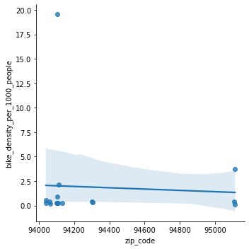

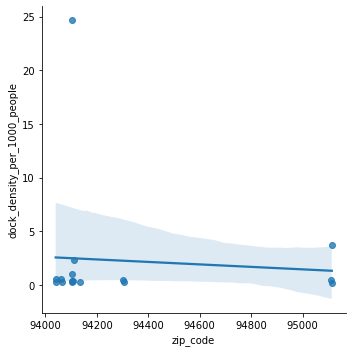

```python
sns.lmplot(x='zip_code',y='bike_density_per_1000_people',data=sg1)
sns.lmplot(x='zip_code',y='dock_density_per_1000_people',data=sg1)
```

As we can see, certain zip codes have a disproportionately high number of bicycles for their populations, whereas most areas hover at less than 1 bike per 1000 people. Further datasets are required at this point to correlate bike and dock availability with economic status. However, based on the analysis above, this low availability of bikes could merely mean that the bikes are heavily utilized within the zip code, or as a means of transportation. However, if we compare this against the number of docks, we see that certain areas also have a disproportionately high number of docks, and these are surprisingly the same areas where the number of bikes available are disproportionately high. We can confirm this by looking at the sg1 dataframe above the plots.

```python
income_dict={'zip_code':[94062,94105,94102,95110,94103,94104,94107,95112,94040,94306,95113,94041,94111,94133,94301,94063],
             'median_income':[125060,163949,22517,63184,43364,48750,114439,48370,99375,110580,34345,92125,89722,50485,122473,52818],
             'median_age':[45,36,41,32,39,48,36,30,36,41,38,35,51,44,43,31]}
income=pd.DataFrame(income_dict)
```

```python
sg1['median_income']=sg1['zip_code'].map(income.set_index('zip_code')['median_income'])
sg1['median_age']=sg1['zip_code'].map(income.set_index('zip_code')['median_age'])
sg1[['zip_code','population','bike_density_per_1000_people','dock_density_per_1000_people','median_income','median_age']]
```

|  | zip_code | population | bike_density_per_1000_people | dock_density_per_1000_people | median_income | median_age |
| --- | --- | --- | --- | --- | --- | --- |
| 4 | 94062 | 28423 | 0.410174 | 0.536476 | 125060 | 45 |
| 9 | 94105 | 10916 | 0.878906 | 1.002970 | 163949 | 36 |
| 6 | 94102 | 31392 | 0.288046 | 0.391511 | 22517 | 41 |
| 15 | 95110 | 19928 | 0.432906 | 0.489113 | 63184 | 32 |
| 7 | 94103 | 30703 | 0.277314 | 0.274711 | 43364 | 39 |
| 8 | 94104 | 429 | 19.544505 | 24.646225 | 48750 | 48 |
| 10 | 94107 | 31461 | 0.263486 | 0.356082 | 114439 | 36 |
| 16 | 95112 | 62228 | 0.131745 | 0.130423 | 48370 | 30 |
| 2 | 94040 | 36526 | 0.224098 | 0.263563 | 99375 | 36 |
| 14 | 94306 | 27435 | 0.291762 | 0.254743 | 110580 | 41 |
| 17 | 95113 | 2107 | 3.740995 | 3.685332 | 34345 | 38 |
| 3 | 94041 | 14572 | 0.532976 | 0.579057 | 92125 | 35 |
| 11 | 94111 | 3611 | 2.148275 | 2.319054 | 89722 | 51 |
| 12 | 94133 | 26796 | 0.275921 | 0.282751 | 50485 | 44 |
| 13 | 94301 | 16582 | 0.425607 | 0.477019 | 122473 | 43 |
| 5 | 94063 | 34867 | 0.202322 | 0.227772 | 52818 | 31 |

Median income and age of zip codes from www.unitedstateszipcodes.org

```python
income_correlation=sg1['median_income'].corr(sg1['bike_density_per_1000_people'])
age_correlation=sg1['median_age'].corr(sg1['bike_density_per_1000_people'])
print('The correlation between income and bike density is: ',income_correlation)
print('The correlation between age and bike density is: ',age_correlation)
```

```
The correlation between income and bike density is:  -0.23354683085525751
The correlation between age and bike density is:  0.4336087986540396
```

## 4) Subscriber behavior

Mine bike share data to define and contrast the behaviour of subscribers and casual users. A through understanding of these two distinct user groups can inform decisions regarding infrastructure investment and pricing that will ultimately:

- best serve the unique needs of frequent and casual users;
- convert casual users to subscribers; and
- expand the overall reach of the service.

```python
df_trip = pd.read_csv('trip.csv', sep=',')
df_station = pd.read_csv('station.csv', sep=',')
```

```python
# Cleaning
df_trip['start_date']= pd.to_datetime(df_trip['start_date']) #Convert start date to datetime
df_trip['end_date']= pd.to_datetime(df_trip['end_date']) #Convert end date to datetime
```

```python
# Feature engineering
df_trip['start_dmy'] =pd.to_datetime(df_trip['start_date'].dt.strftime('%d-%m-%Y')) # day, month, year trip started
df_trip['start_dow'] =df_trip['start_date'].dt.dayofweek # day of week trip started (0-6)
df_trip['start_hod'] =df_trip['start_date'].dt.hour # hour of day trip started (1-24)
```

```python
dictStations = pd.Series(df_station.city.values,index=df_station.name).to_dict()
df_trip['start_city']= df_trip['start_station_name'].map(dictStations) # city trip initiated in
```

**Exploratory Analysis**

```python
# Subscription types present in the dataset
df_trip.subscription_type.unique()
```

```
array(['Subscriber', 'Customer'], dtype=object)
```

**Overall Comparison**

```python
# Trips grouped by subscription type
tripGroups = df_trip.groupby('subscription_type')
```

```python
# Total number of trips taken by subscribers and casual customers
cust_count = tripGroups['id'].count()['Customer']
subs_count = tripGroups['id'].count()['Subscriber']
```

```python
print('Trips taken by casual customers: '+ str(cust_count))
print('Trips taken by subscribers: '+ str(subs_count))
```

```
Trips taken by casual customers: 103213
Trips taken by subscribers: 566746
```

```python
# Proportion of total trips taken by subscribers and casual customers
print('Proportion of trips taken by customers: '+ str(round(cust_count/(subs_count+cust_count)*100,1))+'%')
print('Proportion of trips taken by subscribers: '+ str(round(subs_count/(subs_count+cust_count)*100,1))+'%')
```

```
Proportion of trips taken by customers: 15.4%
Proportion of trips taken by subscribers: 84.6%
```

```python
# Trip duration, subscribers vs. casual customers
print('Median trip duration, customers: ' + str(tripGroups['duration'].median()['Customer']))
print('Median trip duration, subscribers: ' + str(tripGroups['duration'].median()['Subscriber']))
```

```
Median trip duration, customers: 1116.0
Median trip duration, subscribers: 476.0
```

Geographical Comparison

```python
# Trips grouped by subscription type, city
tripGroups1 = df_trip.groupby(['subscription_type', 'start_city'])
tripGroups1b = df_trip.groupby('start_city')
```

```python
# Number of trips taken by customers/subscribers in each city
cust_city_count = tripGroups1['id'].count()['Customer']
subs_city_count = tripGroups1['id'].count()['Subscriber']
city_duration = tripGroups9['duration'].median()
df_city_count = pd.concat([cust_city_count, subs_city_count], axis=1)
df_city_count.columns = ['customers', 'subscribers']
df_city_count['sub_ratio'] = subs_city_count/(cust_city_count+subs_city_count)
df_city_count.head()
```

[output not shown]

```python
# Pie plot of the total trips taken in each city by customers
labels = df_city_count.index
sizes = df_city_count.customers/sum(df_city_count.customers)*100
labels = [f'{l}, {s:0.1f}%' for l, s in zip(labels, sizes)]
pie = plt.pie(sizes,startangle=0)
plt.axis('equal')
plt.legend(bbox_to_anchor=(0.85, 1), loc='upper left', labels=labels)
plt.title('Customer Trips')
plt.show()
```

[output not shown]

```python
# Pie plots of the total trips taken in each city by subscribers
labels2 = df_city_count.index
sizes2 = df_city_count.subscribers/sum(df_city_count.subscribers)*100
labels2 = [f'{l}, {s:0.1f}%' for l, s in zip(labels2, sizes2)]
pie = plt.pie(sizes2,startangle=0)
plt.axis('equal')
plt.legend(bbox_to_anchor=(0.85, 1), loc='upper left', labels=labels2)
plt.title('Subscriber Trips')
plt.show()
```

[output not shown]

```python
# Bar plot of the subscriber ratio (sub trips / all trips) for each city
subRatioPlot = df_city_count.sub_ratio.plot.bar()
subRatioPlot.set_ylabel("Subscriber Ratio")
subRatioPlot.set_xlabel("")
subRatioPlot.plot()
```

[output not shown]

```python
# Bar plot of the median trip duration for each city
df_city_count['duration'] = city_duration
cityPlot = df_city_count.duration.plot.bar()
cityPlot.set_ylabel("Median Trip Duration (s)")
cityPlot.set_xlabel("")
cityPlot.plot()
```

[output not shown]

Long-term Trends

```python
# Trips grouped by subscription type, start date
tripGroups2 = df_trip.groupby(['subscription_type', 'start_dmy'])
```

```python
# Daily trip count, subscribers & customers
cust_count_daily = tripGroups2['id'].count()['Customer']
subs_count_daily = tripGroups2['id'].count()['Subscriber']
df_daily_count = pd.concat([cust_count_daily, subs_count_daily], axis=1)
df_daily_count.columns = ['customers', 'subscribers']
df_daily_count.head()
```

[output not shown]

```python
# Plot of daily trip counts
demandPlot = df_daily_count.plot(style="-o", title="Daily Trip Count")
demandPlot.set_ylabel("# of Trips")
demandPlot.set_xlabel("Time (day)")
```

[output not shown]

```python
# Plot of daily trip count, monthly average
demandPlot2 = df_daily_count.resample('M').mean().plot(style="-o")
demandPlot2.set_ylabel("Trips per Day (#)")
demandPlot2.set_xlabel("Time (month)")
demandPlot2.plot()
```

[output not shown]

```python
# Plot of daily trip count, yearly average
demandPlot3 = df_daily_count.resample('Y').mean().plot(style="-o", title = 'Daily Trip Count')
demandPlot3.set_ylabel("Trips per Day (#)")
demandPlot3.set_xlabel("Time (year)")
demandPlot3.plot()
```

[output not shown]

```python
# Line plot of subscriber ratio over time
df_daily_count['sub_ratio'] = df_daily_count['subscribers']/(df_daily_count['subscribers']+df_daily_count['customers'])
subRatioPlot2 = df_daily_count.sub_ratio.resample('M').mean().plot(style="-o")
subRatioPlot2.set_ylabel("Subscriber Ratio")
subRatioPlot2.set_xlabel("Time (month)")
subRatioPlot2.plot()
```

[output not shown]

```python
# Median trip duration (per day), subscribers & customers
cust_trip_duration = tripGroups2['duration'].median()['Customer']
subs_trip_duration = tripGroups2['duration'].median()['Subscriber']
df_trip_duration = pd.concat([cust_trip_duration, subs_trip_duration], axis=1)
df_trip_duration.columns = ['customers', 'subscribers']
df_trip_duration.head()
```

[output not shown]

```python
# Plot of median trip duration, daily
durationPlot = df_trip_duration.plot(style="-o", title = 'Daily Trip Duration')
durationPlot.set_ylabel("Trip Duration")
durationPlot.set_xlabel("Time (day)")
durationPlot.plot()
```

[output not shown]

```python
# Plot of median trip duration, monthly average
durationPlot2 = df_trip_duration.resample('M').mean().plot(style="-o", title = 'Daily Trip Duration')
durationPlot2.set_ylabel("Median Trip Duration (s)")
durationPlot2.set_xlabel("Time (month)")
durationPlot2.plot()
```

[output not shown]

```python
# Plot of daily trip duration, yearly average
durationPlot3 = df_trip_duration.resample('Y').mean().plot(style="-o", title = 'Daily Trip Duration')
durationPlot3.set_ylabel("Median Trip Duration (s)")
durationPlot3.set_xlabel("Time (year)")
durationPlot3.plot()
```

[output not shown]

Seasonal Variation

```python
# Trips grouped by subscription type and weekday
tripGroups3 = df_trip.groupby(['subscription_type', 'start_dow'])
```

```python
# Total trip count by weekday
cust_dow_count = tripGroups3['id'].count()['Customer']
subs_dow_count = tripGroups3['id'].count()['Subscriber']
df_dow_count = pd.concat([cust_dow_count, subs_dow_count], axis=1)
df_dow_count.columns = ['customers', 'subscribers']
df_dow_count.head()
```

[output not shown]

```python
# Bar plot of trip count by weekday
dowPlot = df_dow_count.plot.bar()
dowPlot.set_ylabel("Trip Count (#)")
dowPlot.set_xlabel("Day of Week")
dowPlot.plot()
```

[output not shown]

```python
# Trips grouped by subscription type and hour of day
tripGroups4 = df_trip.groupby(['subscription_type', 'start_hod'])
```

```python
# Total trip count by hour of day
cust_hod_count = tripGroups4['id'].count()['Customer']
subs_hod_count = tripGroups4['id'].count()['Subscriber']
df_hod_count = pd.concat([cust_hod_count, subs_hod_count], axis=1)
df_hod_count.columns = ['customers', 'subscribers']
df_hod_count.head()
```

[output not shown]

```python
# Bar plot of trip count by hour of day
hodPlot = df_hod_count.plot.bar()
hodPlot.set_ylabel("Trip Count (#)")
hodPlot.set_xlabel("Hour of Day")
hodPlot.plot()
```

[output not shown]